# DESeq2 Analyses: *Megalopta genalis*

KS Geist

8 February 2021

```r
knitr::opts_chunk$set(echo = TRUE)
```

## Getting Started

#### Raw Count Data

First, read in the raw count data:

```r
## Clear workspace
rm(list=ls())

## Import data
hymn <- read.table("Mgenalis_merged_gene_counts.txt", header = T, sep = "\t")

## Need to remove an unecessary second column & save the gene IDs as a vector for the row names:
geneID <- hymn[,1]
hymn <- hymn[,-c(1:2)]

## Rename the headers to the sample names:
names(hymn)
```

```
##  [1] "SRR3948565_1Aligned.sortedByCoord.out.bam"
##  [2] "SRR3948538_1Aligned.sortedByCoord.out.bam"
##  [3] "SRR3948545_1Aligned.sortedByCoord.out.bam"
##  [4] "SRR3948582_1Aligned.sortedByCoord.out.bam"
##  [5] "SRR3948555_1Aligned.sortedByCoord.out.bam"
##  [6] "SRR3948573_1Aligned.sortedByCoord.out.bam"
##  [7] "SRR3948561_1Aligned.sortedByCoord.out.bam"
##  [8] "SRR3948557_1Aligned.sortedByCoord.out.bam"
##  [9] "SRR3948523_1Aligned.sortedByCoord.out.bam"
## [10] "SRR3948546_1Aligned.sortedByCoord.out.bam"
## [11] "SRR3948522_1Aligned.sortedByCoord.out.bam"
## [12] "SRR3948569_1Aligned.sortedByCoord.out.bam"
## [13] "SRR3948553_1Aligned.sortedByCoord.out.bam"
## [14] "SRR3948559_1Aligned.sortedByCoord.out.bam"
## [15] "SRR3948567_1Aligned.sortedByCoord.out.bam"
## [16] "SRR3948524_1Aligned.sortedByCoord.out.bam"
## [17] "SRR3948525_1Aligned.sortedByCoord.out.bam"
## [18] "SRR3948578_1Aligned.sortedByCoord.out.bam"
## [19] "SRR3948571_1Aligned.sortedByCoord.out.bam"
## [20] "SRR3948574_1Aligned.sortedByCoord.out.bam"
## [21] "SRR3948551_1Aligned.sortedByCoord.out.bam"
## [22] "SRR3948541_1Aligned.sortedByCoord.out.bam"
## [23] "SRR3948543_1Aligned.sortedByCoord.out.bam"
## [24] "SRR3948576_1Aligned.sortedByCoord.out.bam"
## [25] "SRR3948532_1Aligned.sortedByCoord.out.bam"
## [26] "SRR3948549_1Aligned.sortedByCoord.out.bam"
## [27] "SRR3948530_1Aligned.sortedByCoord.out.bam"
## [28] "SRR3948535_1Aligned.sortedByCoord.out.bam"
## [29] "SRR3948534_1Aligned.sortedByCoord.out.bam"
## [30] "SRR3948580_1Aligned.sortedByCoord.out.bam"
```

```r
colnames(hymn) <- c("SRR3948565", "SRR3948538", "SRR3948545", "SRR3948582", "SRR3948555", "SRR3948573", "SRR3948561", "SRR3948557", "SRR3948523", "SRR3948546", "SRR3948522", "SRR3948569", "SRR3948553", "SRR3948559", "SRR3948567", "SRR3948524", "SRR3948525", "SRR3948578", "SRR3948571", "SRR3948574", "SRR3948551", "SRR3948541", "SRR3948543", "SRR3948576", "SRR3948532", "SRR3948549", "SRR3948530", "SRR3948535", "SRR3948534", "SRR3948580")

## At the moment, we have more samples than desired for repro vs. nonrepro. So, let's just grab the columns we want:
hymn <- hymn[,c("SRR3948522", "SRR3948580", "SRR3948532", "SRR3948545", "SRR3948559", "SRR3948571", "SRR3948576", "SRR3948523", "SRR3948530", "SRR3948535", "SRR3948538", "SRR3948546", "SRR3948551", "SRR3948569")]
#names(hymn)

## Next, move the gene IDs to the row names instead of as a column:
rownames(hymn) <- geneID

## Check that the df looks as expected:
head(hymn)
```

```
##                   SRR3948522 SRR3948580 SRR3948532 SRR3948545 SRR3948559
## gene-LOC117217331          0          0          0          0          0
## gene-LOC117218034          0          0          0          0          0
## gene-LOC117218713          1          0          0          0          0
## gene-LOC117221120          0          0          0          0          0
## gene-LOC117220716         27          0          0          0          0
## gene-LOC117221797         57          6          0          0          1
##                   SRR3948571 SRR3948576 SRR3948523 SRR3948530 SRR3948535
## gene-LOC117217331          0          0          0          0          0
## gene-LOC117218034          0          0          0          0          0
## gene-LOC117218713          1          0          0          0          0
## gene-LOC117221120          0          0          0          0          0
## gene-LOC117220716          0         43          0          0          0
## gene-LOC117221797          0         27          0          2          0
##                   SRR3948538 SRR3948546 SRR3948551 SRR3948569
## gene-LOC117217331          0          0          0          0
## gene-LOC117218034          0          0          0          0
## gene-LOC117218713          1          0          0          0
## gene-LOC117221120          2          0          0          0
## gene-LOC117220716         34          0         34          0
## gene-LOC117221797         31          0         31          0
```

I’ve noticed that very few of the genes seem to have zero counts.

```r
## How many total genes:
nrow(hymn)
```

```
## [1] 12793
```

```r
## One quick quality check: how many of my gene counts are zero for all samples?
totalCounts <- rowSums(hymn)
length(totalCounts[totalCounts == 0])
```

```
## [1] 850
```

```r
## Proportion of all genes not expressed AT ALL:
length(totalCounts[totalCounts == 0]) / length(totalCounts)
```

```
## [1] 0.06644259
```

```r
## How about if we have 0 counts for ANY of the samples?
anyZero <- colSums(hymn == 0)
anyZero ## the number of zeros seen in each column
```

```
## SRR3948522 SRR3948580 SRR3948532 SRR3948545 SRR3948559 SRR3948571 SRR3948576
##       1808       5309       5437       5536       5161       5451       1924
## SRR3948523 SRR3948530 SRR3948535 SRR3948538 SRR3948546 SRR3948551 SRR3948569
##       5526       5661       5421       2077       5451       1954       5623
```

```r
## Now, let's get a proportion of any gene in any sample that was 0:
sum(anyZero) / sum(hymn)
```

```
## [1] 0.001640977
```

```r
## Read count by phenotype (first 7 are R's, second 7 are NR's)
sum(hymn[,c(1:7)])
```

```
## [1] 19987745
```

```r
sum(hymn[,c(8:14)])
```

```
## [1] 18001212
```

```r
# Total read count:
sum(hymn)
```

```
## [1] 37988957
```

#### Create the phenotype metadata

Create the pheno metadata, making sure that the row names of the metadata dataframe are present and in the same order as the column names of the counts dataframe:

```r
id <- c("SRR3948522", "SRR3948580", "SRR3948532", "SRR3948545", "SRR3948559", "SRR3948571", "SRR3948576", "SRR3948523", "SRR3948530", "SRR3948535", "SRR3948538", "SRR3948546", "SRR3948551", "SRR3948569")
phenotype <- c(rep("R",7), rep("NR", 7))

pheno <- as.data.frame(phenotype)
row.names(pheno) <- id
#pheno

colnames(hymn)
```

```
##  [1] "SRR3948522" "SRR3948580" "SRR3948532" "SRR3948545" "SRR3948559"
##  [6] "SRR3948571" "SRR3948576" "SRR3948523" "SRR3948530" "SRR3948535"
## [11] "SRR3948538" "SRR3948546" "SRR3948551" "SRR3948569"
```

```r
# Notice that the DF is analogous to the expression data

# Check that the column names of the counts df are the same and in the same order as the phenotypes df:
all(colnames(hymn) %in% rownames(pheno))
```

```
## [1] TRUE
```

```r
all(colnames(hymn) == rownames(pheno))
```

```
## [1] TRUE
```

## Run DESeq2

Construct DESEQDataSet Object (stored as dds):

```r
dds <- DESeqDataSetFromMatrix(countData=hymn,
                              colData=pheno,
                              design=~phenotype)
## Converts counts to integer mode??

## Design specifies how the counts from each gene depend on our variables in the metadata; we currently only have one factor of interest, phenotype

## tidy=TRUE argument tells DESeq2 to output the results table with rownames as a first column called 'row; alternatively, I could have used that argument here to move the first col into the rownames of each dataset.

## Check the structure of the object:
#str(dds)

## Extract information from the object, if desired:
#counts(dds) ## extracts back out the original counts matrix
```

#### Run DESeq Function

- **Performs normalization (median of ratios):** 1.Corrects for variance in read sequencing depth 2.Corrects for inter-library dispersion in counts (for each gene)
- **Calculates the significance of coefficients with a negative binomial GLM**

Note that DESeq2 does not actually use the normalized counts but rather uses the raw counts and models the normalization in the negative binomial model.

```r
## Yes, we are overwriting / performing the functions on the dataset object
dds <- DESeq(dds)
```

```
## -- replacing outliers and refitting for 43 genes
## -- DESeq argument 'minReplicatesForReplace' = 7
## -- original counts are preserved in counts(dds)
```

```r
## Note that normalization only could be performed as follows:
# dds <- estimateSizeFactors(dds)
# sizeFactors(dds)

## Let's extract the normalized counts (from either the DESeq() function or the estimateSizeFactors() function, whichever was used above):
normalized_counts <- counts(dds, normalized=TRUE)
#View(normalized_counts)
write.table(normalized_counts, file="normalized_counts.txt", sep="\t", quote=F, col.names=NA)

## I would also like to write the results file for future use / reference:
ddsResults <- results(dds)
write.table(ddsResults, file="DESeq2_results.txt", sep="\t", quote=F, col.names=NA)
```

## More Quality Control & Visualizing Gene & Sample-Wise Variation

#### Estimating Gene-Wise Dispersion

DESeq2 uses a specific measure of dispersion ($\alpha$) related to the mean ($\mu$) and variance of the data: $\sigma^2 = \mu + \alpha * \mu^2$. This means that genes with moderate to high counts, the square root of dispersion ($\alpha$) equals the Coefficient of Variation ($CV = \sigma^2 / \mu$). Thus, a 0.01 dispersion means there is 10% variation around the mean expected across biological replicates.

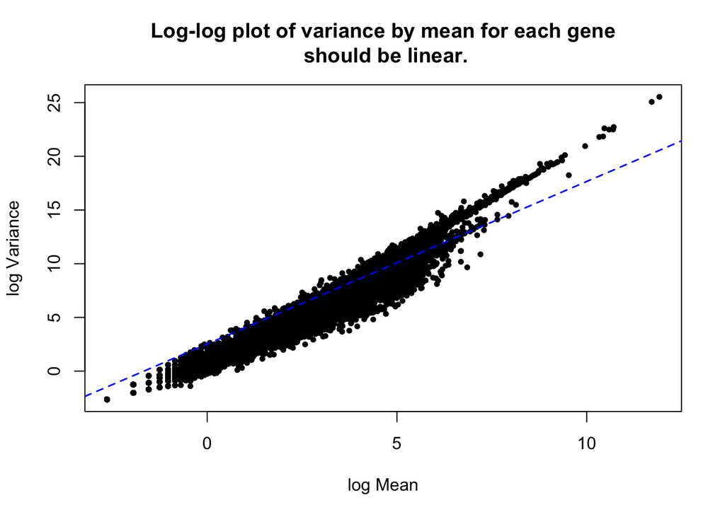

```r
meanCounts <- rowMeans(hymn)
varCounts <- apply(hymn, 1, var)  ## Apply the variance function by margin = 1, which is rows
plot(log(varCounts)~log(meanCounts), ylab = "log Variance", xlab = "log Mean", main = "\nLog-log plot of variance by mean for each gene\n should be linear.\n", pch = 16, cex = 0.75)
abline(lm(log(varCounts+0.0001)~log((meanCounts+0.0001))), col = "blue", lty = 2, lwd = 1.5)
```

The relationship between mean and variance should be linear on the log scale, and in gene expression data we predict that for higher means, we can more accurately predict the variance (it should be fanned out at lower means and a tighter relationship at higher means). We expect that for low mean counts, the variance estimates have a much larger spread, such that the dispersion estimates will differ much more between genes with small means.

Hopefully, a variance-stabilizing transformation will help to resolve this issue.

All of the variance stabilizing transformation (VST) functions provided by DESeq2 attempt to shrink the gene-wise dispersion. **Note: there are compelling arguments that these VSTs do a better job than a mixed model would, which is why we do not / cannot add random effects to our NB model.**

When we perform the VST & visualize it, we can ensure that our data are a good fit for DESeq2. In Visualization, the VST will allow us to more accurately identify DE genes. The shrinkage is being performed in the NB model as part of the DESeq2 function, which is important to reduce false positives.

What does the plot of our dispersion estimates look like after model-fitting?

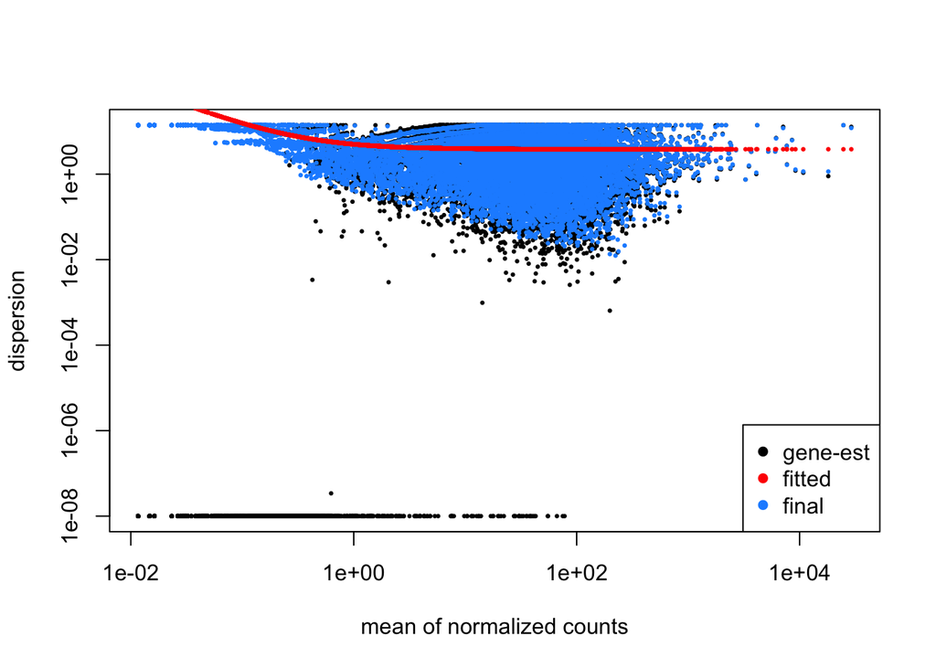

```r
plotDispEsts(dds)
```

#### Variance Transformations

Transformations: Variance Stabilizing Functions - Parametric Fit ### Note that all transformations have set blind = FALSE. We do not want the transformations to be blind to the experimental design (phenotypes) at this point; we expect large differential expression in some genes, and so we need to control for outliers by setting blind to FALSE.

```r
#vsdata <- vst(dds, blind=FALSE)
## This is a quicker function but not as thorough
vsdata1 <- varianceStabilizingTransformation(dds, blind = FALSE, fitType = "parametric")
meanSdPlot(assay(vsdata1))
```

[output not shown]

Transformations: Variance Stabilizing Functions - Local Fit

```r
vsdata2 <- varianceStabilizingTransformation(dds, blind = FALSE, fitType = "local")
meanSdPlot(assay(vsdata2))
```

[output not shown]

Transformations: Variance Stabilizing Functions - Mean Type

```r
vsdata3 <- varianceStabilizingTransformation(dds, blind = FALSE, fitType = "mean")
meanSdPlot(assay(vsdata3))
```

[output not shown]

Transformations: Regularized Log, recommended for smaller numbers of samples

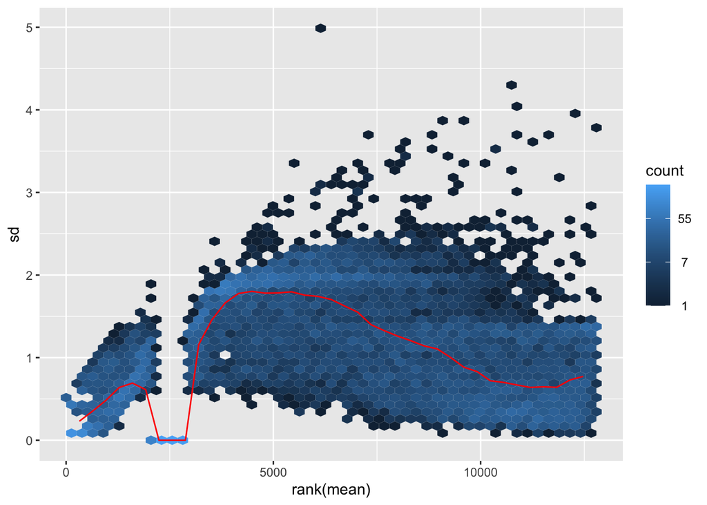

```r
rld <- rlog(dds, blind = FALSE)
meanSdPlot(assay(rld))
```

Heuristically, they all appear to do well except rld, but there is a lot more dispersion in this dataset than some of the others. Let’s just stick with the parametric VST.

```r
#save(vsdata1, file = "Mgenalis_VarStab.RData")
write.csv(file = "Mgenalis_VarStab.csv", assay(vsdata1), row.names = T, quote = F)
```

#### Principal Component Analysis

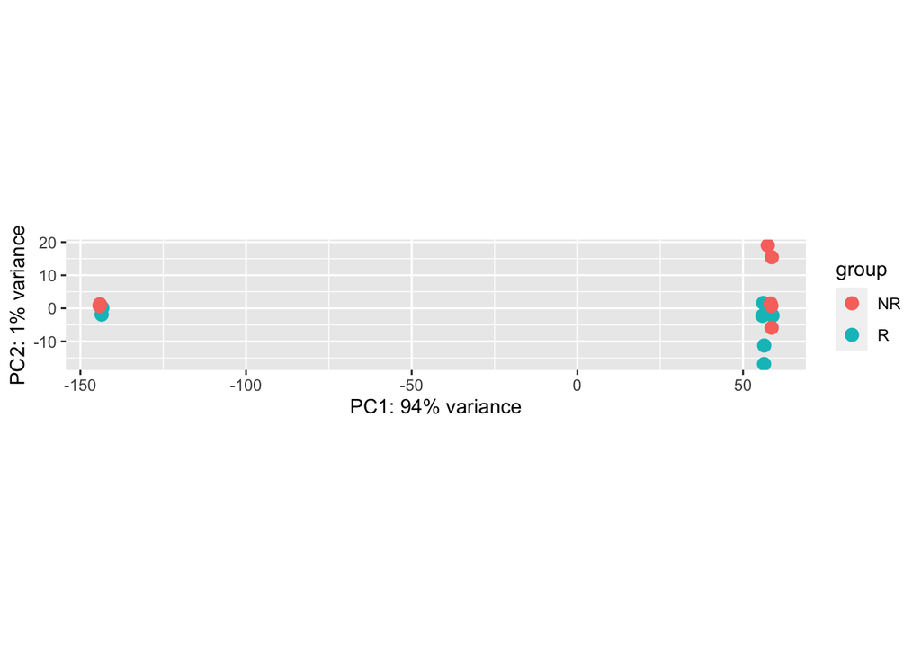

```r
plotPCA(vsdata1, intgroup="phenotype", ntop = 300)
```

```r
## I have changed ntop from the default of 500 to 300 because we're not anticipating huge numbers of DE genes. ntop plots the top XX most variable genes in the dataset.
```

Ouch. Something is going on! The phenotypes don’t cluster distinctly.

**Hierarchical Clustering** There is no built-in function for heatmaps in DESeq2 so let’s use the pheatmap() function from the pheatmap package.

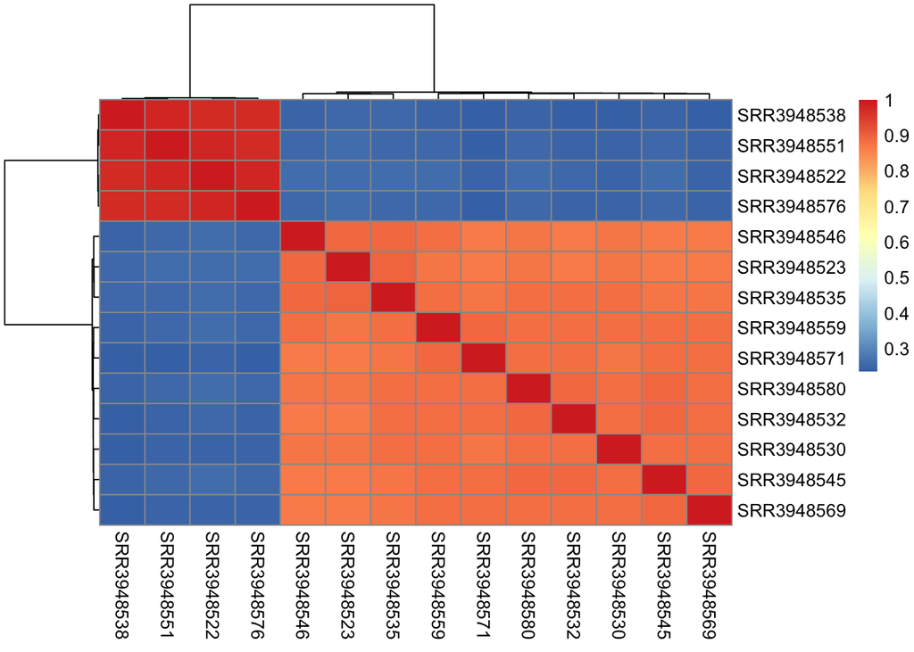

```r
## It requires a matrix/dataframe of numeric values as input, which we can extract with the assay() function from our VST object.
vsdata1.assay <- assay(vsdata1)

## Compute  pairwise correlation values for samples:
pwCorr <- cor(vsdata1.assay)
#pwCorr   ## check the output, make note of the rownames and colnames

## Lastly, let's make our heatmap!
pheatmap(pwCorr)
```

The clustering is very distinct, but it does not go with our phenotypes. SRR3948538 & SRR3948551 are both workers. SRR3948522 & SRR3948576 are both queens. We see the same clustering in that PCA above.

Note that in the original paper, brain gene expression was not highly variable (surprising?) and that they saw the least variation in expression in the brains of queens and workers. I think we’re just picking up on that here too.

#### Calculating Log-fold Change & Getting DE Genes

In the original DESeq2 paper, the authors shrink the log-fold change estimates toward zero for genes with low counts and/or high dispersion values. It uses the distribution of LFC estimates as a prior to perform this shrinkage. In the most recent versions of DESeq2, the shrinkage of LFC estimates is not performed by default.

```r
## These are the LFC estimates without shrinkage:
#LFC <- ddsResults$log2FoldChange

## These are the LFC results with shrinkage:
#shrunkenLFC <- lfcShrink(dds = dds, coef = 1)
#shrunkenLFC
```

*However, note that these shrunked LFC values will not change the number of DE genes. The reason to do this is for additional downstream assessments. For example, if you wanted to subset your sig genes based on foldchange for further evaluation, you would want to use these values instead.*

##### Numbers of DE Genes Based on Fold-Change (Wald Tests)

Since we want a standardized way to retrieve DE genes for all our species, rather than using the commonly used Tibble filtering people will do, we will do hypothesis tests using set significance and log-fold change thresholds. This is a more conservative approach, so you will receive fewer genes than with the Tibble filtering method.

Quick breakdown of LFC:

```r
linear.changes <- c(1.5, 2, 2.5, 3, 4)
lfc.thresholds <- log(linear.changes, base = 2)
lfc.thresholds
```

```
## [1] 0.5849625 1.0000000 1.3219281 1.5849625 2.0000000
```

```r
## Thus, a LFC of 0.58 is equivalent to a linear fold change of 1.5 in the gene expression value.
```

```r
## This performs a Wald test of the specified contrast with a set significance threshold and a LFC threshold
## Can use a theshold of 0.05 since they use a BH adjustment to the p-value
foldchange <- results(dds, alpha = 0.05, lfcThreshold = 0.58)
#head(foldchange, tidy = T)
summary(foldchange)
```

```
##
## out of 11943 with nonzero total read count
## adjusted p-value < 0.05
## LFC > 0.58 (up)    : 0, 0%
## LFC < -0.58 (down) : 0, 0%
## outliers [1]       : 0, 0%
## low counts [2]     : 0, 0%
## (mean count < 0)
## [1] see 'cooksCutoff' argument of ?results
## [2] see 'independentFiltering' argument of ?results
```

```r
## Function to calculate the number of DE genes for each of the LFC values:
LFC.df <- NULL
DEGenumerator <- function(dds) {
  for (i in 1:length(lfc.thresholds)) {
    ## Do the Wald tests with each of the LFC thresholds you want to try
    foldchange <- results(dds, alpha = 0.05, lfcThreshold = lfc.thresholds[i])
    ## Get the total number of DE genes
    total <- nrow(subset(foldchange, padj < 0.05))
    ## Get the up genes, greater than the positive LFC threshold
    up <- nrow(subset(foldchange, padj < 0.05 & log2FoldChange > lfc.thresholds[i]))
    ## Get the down genes, less than the negative LFC threshold
    down <- nrow(subset(foldchange, padj < 0.05 & log2FoldChange < -lfc.thresholds[i]))
    ## Put in a dataframe:
    LFC.df <- rbind(LFC.df, c(lfc.thresholds[i], linear.changes[i], total, up, down, "Mgenalis"))
  }
  return(as.data.frame(LFC.df))
}

LFC.df <- DEGenumerator(dds)
names(LFC.df) <- c("LFC.threshold", "Linear.Change", "Total.DEGs", "Up.DEGs", "Down.DEGs", "Species")
LFC.df
```

```
##       LFC.threshold Linear.Change Total.DEGs Up.DEGs Down.DEGs  Species
## 1 0.584962500721156           1.5          0       0         0 Mgenalis
## 2                 1             2          0       0         0 Mgenalis
## 3  1.32192809488736           2.5          0       0         0 Mgenalis
## 4  1.58496250072116             3          0       0         0 Mgenalis
## 5                 2             4          0       0         0 Mgenalis
```

```r
## Writes the number of DEGs to an appended file in the DEG main directory
#write.table(LFC.df, file = "../DEG_counts.txt", append = T, quote = F, row.names = F, col.names = T)
```

#### The *post hoc* Filtering Method

```r
## Set the contrast of interest (R vs. NR). Contrasts are of the form ("sample_type", "contrast2compare", "base_condition")
contrastRNR <- c("phenotype", "R", "NR")
## Note: if I don't set my contrast, it will default to taking the lowest category alphabetically as the base  condition

## To filter the ddsResults based on an FDR of 0.05 (versus 0.1, which is the default) we also need to set the alpha parameter to 0.05 before running the results() function:
#ddsResults <- results(dds, alpha = 0.05)
ddsResults <- results(dds, contrast = contrastRNR, alpha = 0.05)
## Allows us to see the outcome / verify the correct contrast was made
#mcols(ddsResults, use.name = T)

## Note that if you do not set alpha = 0.05, it's doing the Benjamini-Hochberg adjustment at 0.1. This means that the results of your filtering will likely be different.

### Set thresholds
padj.cutoff <- 0.05
lfc.cutoff <- 1

## Let's add the row names (gene IDs) back to the results table as a column:
ddsResults$geneID <- row.names(ddsResults)
#names(ddsResults)

## I see a full range of adjusted p-values at this stage.
#hist(ddsResults$padj, col = "lightgray")
#abline(v = 0.05, col = "red", lwd = 2, lty = 2)

## I also see a full range of LFC values at this stage.
#hist(ddsResults$log2FoldChange, col = "lightgray")
#abline(v = c(lfc.cutoff, -lfc.cutoff), col = "blue", lwd = 2, lty = 2)

## P-value filtering only:
sigDGE <- subset(ddsResults, padj < padj.cutoff)
#hist(sigDGE$log2FoldChange, col = "lightgray", breaks = 50)
#abline(v = c(lfc.cutoff, -lfc.cutoff), col = "blue", lwd = 2, lty = 2)

## How many of these are DEGs?
nrow(sigDGE)
```

```
## [1] 0
```

```r
## How many up?
nrow(subset(sigDGE, log2FoldChange > 0))
```

```
## [1] 0
```

```r
## How many down?
nrow(subset(sigDGE, log2FoldChange < 0))
```

```
## [1] 0
```

```r
## Summary statistics of the LFC for the p-value filtered data. Make sure to do it on the absolute value of the LFC, or you will get the wrong mean.
summary(abs(sigDGE$log2FoldChange))
```

```
##    Min. 1st Qu.  Median    Mean 3rd Qu.    Max.
##
```

```r
## Filter on both the p-value & an LFC of the absolute value of the minimal cutoff:
sigDGE <- subset(ddsResults, padj < padj.cutoff & abs(log2FoldChange) > lfc.cutoff)
# hist(sigDGE$padj, col = "lightgray", breaks = 50)
# abline(v = padj.cutoff, col = "blue", lwd = 2, lty = 2)

## How many of these are DEGs?
nrow(sigDGE)
```

```
## [1] 0
```

```r
## How many up?
nrow(subset(sigDGE, log2FoldChange > lfc.cutoff))
```

```
## [1] 0
```

```r
## How many down?
nrow(subset(sigDGE, log2FoldChange < -lfc.cutoff))
```

```
## [1] 0
```

```r
## Filter based on the LFC cutoff only:
# sigDGE <- subset(ddsResults, abs(log2FoldChange) > lfc.cutoff)
# hist(sigDGE$padj, col = "lightgray", breaks = 50)
# abline(v = padj.cutoff, col = "blue", lwd = 2, lty = 2)

# ## How many of these are DEGs?
# nrow(sigDGE)
# ## How many up?
# nrow(subset(sigDGE, padj > padj.cutoff))
# ## How many down?
# nrow(subset(sigDGE, padj < padj.cutoff))
# ## This verifies that number.
```

Sort log fold change results by adjusted p-value

```r
foldchange <- foldchange[order(foldchange$padj),]
head(foldchange, 3)
```

```
## log2 fold change (MLE): phenotype R vs NR
## Wald test p-value: phenotype R vs NR
## DataFrame with 3 rows and 6 columns
##                             baseMean      log2FoldChange            lfcSE
##                            <numeric>           <numeric>        <numeric>
## gene-LOC117218713  0.161120438403377   0.256921831146274  2.4426807320657
## gene-LOC117221120 0.0296033946844501  -0.639099226673422 3.05044845896099
## gene-LOC117220716   2.01772530728702 0.00111579664329878 2.22070728803849
##                                  stat           pvalue      padj
##                             <numeric>        <numeric> <numeric>
## gene-LOC117218713                   0                1         1
## gene-LOC117221120 -0.0193739469682931 0.98454279381483         1
## gene-LOC117220716                   0                1         1
```

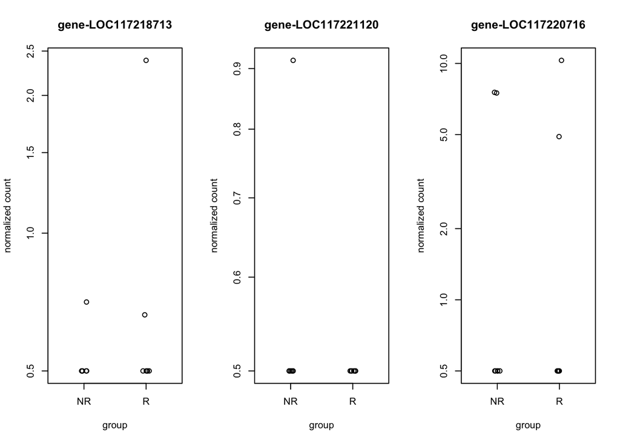

```r
#Compare the normalized counts between our two groups
par(mfrow=c(1,3))

plotCounts(dds, gene="gene-LOC117218713", intgroup="phenotype")
plotCounts(dds, gene="gene-LOC117221120", intgroup="phenotype")
plotCounts(dds, gene="gene-LOC117220716", intgroup="phenotype")
```

#### Volcano Plot

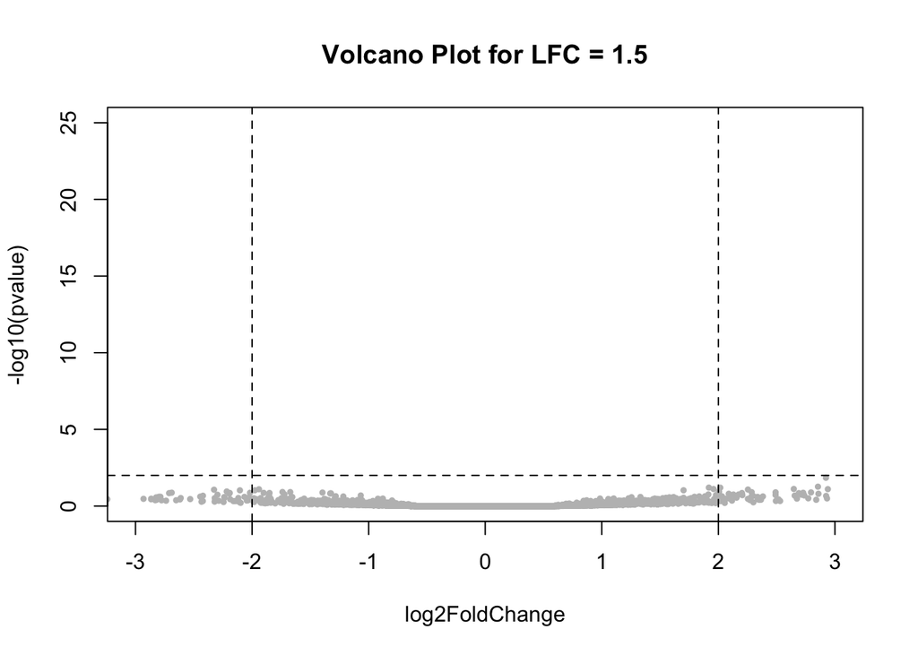

```r
# Make a basic volcano plot
with(foldchange, plot(log2FoldChange, -log10(pvalue), pch=20, cex = 0.75, main="Volcano Plot for LFC = 1.5", xlim=c(-3,3), col ="gray", ylim=c(0,25)))

# Add colored points: blue if padj<0.01, orange if log2FC > 1.5 and padj<0.05)
with(subset(foldchange, padj<.05), points(log2FoldChange, -log10(pvalue), pch=20, col="blue"))
with(subset(foldchange, padj<.05 & abs(log2FoldChange)>1.5), points(log2FoldChange, -log10(pvalue), pch=20, col="orange"))

abline(v=c(-2, 2), col = "black", lty = 2)
abline(h=-log10(0.01), col = "black", lty = 2)
```